# A Pipeline for Agile Estimation of Land Accounts (PAELA)

## Predictions with the RF SMOTE model

```r
# Export Prediction with SMOTE as TIFF
smote_result <- predict(img,
                  rf_fit_smote,
                  filename = paste0("Data/",MyDir,"/Predictions_with_R",StudyYear,"/classification_fromsmote.tif"),
                  overwrite = TRUE
                  )
```

```r
Table_result_smote <- as.data.frame(smote_result) %>%
  mutate(class =  as.factor(classification_fromsmote))

# We affect labels as defined by class_labels, to the variable class

Table_result_smote$class <- factor(Table_result_smote$class, levels = names(class_labels), labels = class_labels)
```

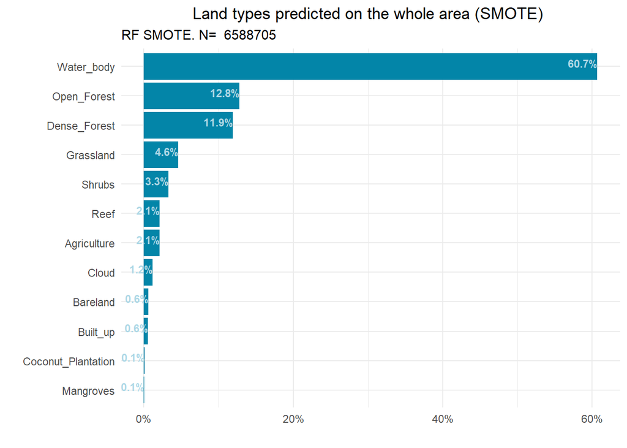

```r
# Create a table of class proportions
prop_table_smote <- tibble(Class = factor(Table_result_smote$class)) %>%
  count(Class) %>%
  mutate(Proportion = n / sum(n)) %>%
  arrange(desc(Proportion))


prop_table_smote %>%
  filter(!is.na(Class))%>%
  ggplot()+
  aes(x = reorder(Class, Proportion), y = Proportion) +
  geom_bar(stat = "identity", fill = SIAP.color) +
   geom_text(aes(label = scales::percent(Proportion, accuracy = 0.1)),
            vjust = 0.1, hjust = +1,  size = 3, color= "lightblue", fontface = "bold") +
  scale_y_continuous(labels = scales::percent_format()) +
  theme_minimal() +
  coord_flip()+
  theme(plot.title = element_text(hjust = 0.5))+
  labs(x = "", y = "", subtitle = paste ( "RF SMOTE. N= ", nrow(Table_result_smote)))  +
  ggtitle("Land types predicted on the whole area (SMOTE) ")
```

## Visualizing the predictions on a MAP

```r
# Read the TIFF file from the Random forest model
raster_data <- terra::rast(paste0("Data/",MyDir,"/Predictions_with_R",StudyYear,"/classification_fromRF.tif"))

# Convert the raster to a data frame for ggplot2
raster_df_RF <- as.data.frame(raster_data, xy = TRUE)


# define the color palette associated with classes
class_colors <- c(
   '#4d926f',  # Dense Forest
   '#6dcf9c',  # Open Forest
   '#3a5739',  # Mangroves
   '#d2c212',  # Agriculture
   '#e44ae7',  # Coconut Plantation
   '#848099',  # Grassland
   '#dc1010',  # Built-up Infrastructure
   '#008aa2',  # Water Body
    '#d7b084',  # Shrubs
    '#a06620',  # Bareland
    '#fcfefc',  # Cloud
    '#9bd9e1'  # Reef
)

# Convert raster values to a factor with labels
raster_df_RF$classification_fromRF <- factor(raster_df_RF$classification_fromRF, levels = names(class_labels), labels = class_labels)
```

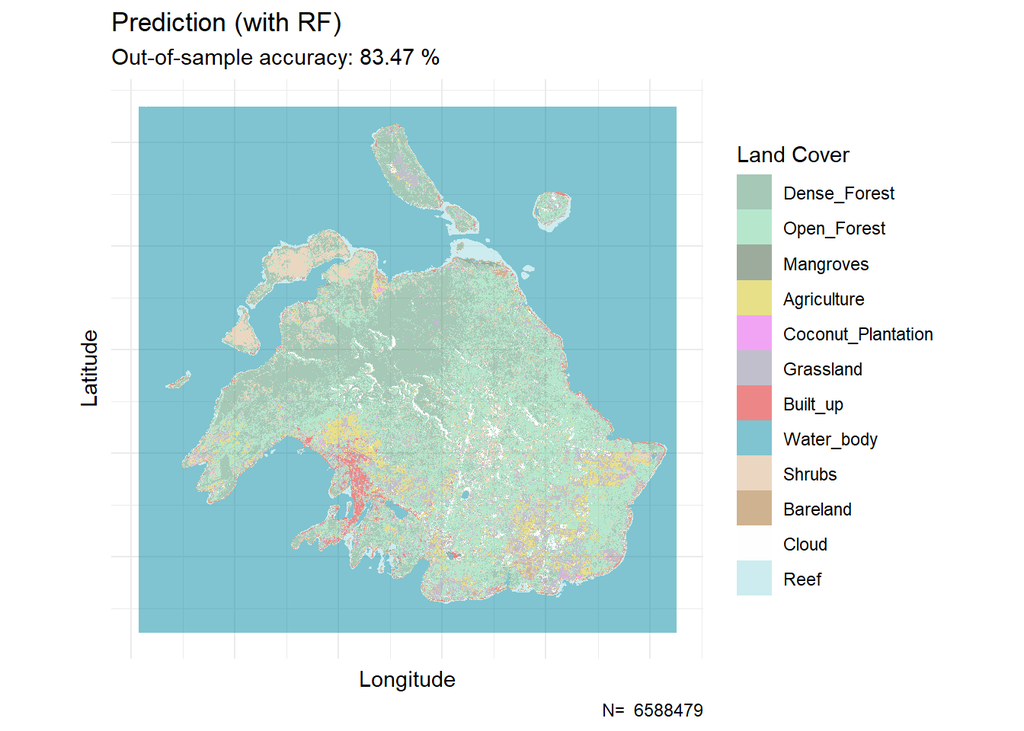

```r
# Plot using ggplot2
p_RF <- ggplot() +
  geom_raster(data = raster_df_RF, aes(x = x, y = y, fill = classification_fromRF), alpha = 0.5 ) +
  scale_fill_manual(values = class_colors, name = "Land Cover") +
  coord_fixed() +
  theme_minimal() +
  labs(title = "Prediction (with RF) ",
       subtitle = paste("Out-of-sample accuracy:", as.character(100*round(rf_CM$overall[1], 4)),"%" ),
       caption =  paste ( "N= ", nrow(raster_df_RF)),
       x = "Longitude",
       y = "Latitude")+
  theme(axis.text.x=element_blank(),
        axis.ticks.x=element_blank(),
        axis.text.y=element_blank(),
        axis.ticks.y=element_blank())
# Plot
p_RF
```

### Predictions of the SMOTE model

```r
# Read the TIFF file from the RF SMOTE  model
raster_data_smote<- rast(paste0("Data/",MyDir,"/Predictions_with_R",StudyYear,"/classification_fromsmote.tif"))

# Convert the raster to a data frame for ggplot2
raster_df_smote <- as.data.frame(raster_data_smote, xy = TRUE)

# Convert raster values to a factor with labels
raster_df_smote$classification_fromsmote <- factor(raster_df_smote$classification_fromsmote, levels = names(class_labels), labels = class_labels)
```

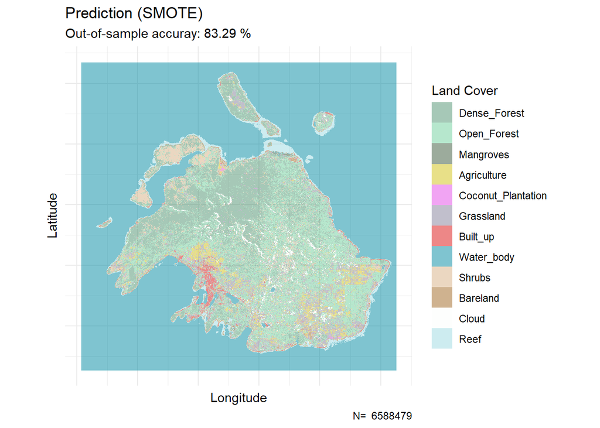

```r
# Plot using ggplot2
p_smote <- ggplot() +
  geom_raster(data = raster_df_smote, aes(x = x, y = y, fill = classification_fromsmote), alpha = 0.5 ) +
  scale_fill_manual(values = class_colors, name = "Land Cover") +
  coord_fixed() +
  theme_minimal() +
  labs(title = "Prediction (SMOTE) ",
       subtitle = paste("Out-of-sample accuray:", as.character(100*round(smote_CM$overall[1], 4)),"%" ),
       caption =  paste ( "N= ", nrow(raster_df_smote)),
       x = "Longitude",
       y = "Latitude")+
  theme(axis.text.x=element_blank(),
        axis.ticks.x=element_blank(),
        axis.text.y=element_blank(),
        axis.ticks.y=element_blank())
# Plot
p_smote
```

## Comparing models

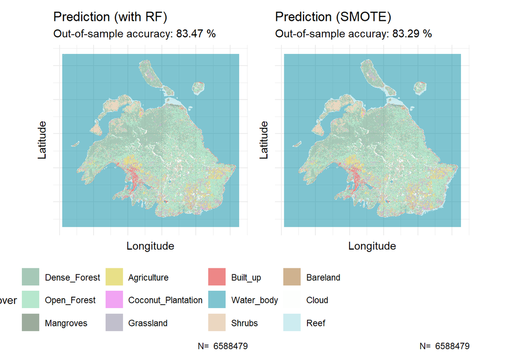

```r
# Combine the plots
# removing the legend for one plot
p_RF <- p_RF + theme(legend.position = "bottom")
p_smote <- p_smote + theme(legend.position = "none")


RFvssmote <- (p_RF |  p_smote)

# Display the combined plot
print(RFvssmote)
```

```r
# Merge the data frames on x and y coordinates
combined_df <- raster_df_RF %>%
  inner_join(raster_df_smote, by = c("x", "y")) %>%
  rename(prediction_RF = classification_fromRF,
         prediction_smote = classification_fromsmote)

# Create a new column indicating whether the predictions are the same or different
# the NEW class is 0!!
combined_df <- combined_df %>%
  mutate(diff = ifelse(prediction_RF == prediction_smote, "Identical", "Change"))%>%
  # mutate(diff_class = prediction_RF) %>%
  mutate(diff_class = case_when(
    prediction_RF != prediction_smote ~ "Difference",
    TRUE ~ prediction_RF  # Keep original values if condition is not met
))



# Define the  augmented color class labels with the category "Difference"
class_labels_N <-  c(
"0" = "Difference",
"1" = "Dense_Forest",
"2" = "Open_Forest",
#"3" = "Forest_plantation",
"4" = "Mangroves",
"5" = "Agriculture",
"6" = "Coconut_Plantation",
"7" = "Grassland",
"8" = "Built_up",
"9" = "Water_body",
"10" = "Shrubs",
"11" = "Bareland",
"12" = "Cloud",
"13" = "Reef"
)

# Define the augmented color palette accordingly
class_colors_N  <- c(
   "#FFA500",  # Difference
   '#4d926f',  # Dense Forest
   '#6dcf9c',  # Open Forest
   '#3a5739',  # Mangroves
   '#d2c212',  # Agriculture
   '#e44ae7',  # Coconut Plantation
   '#848099',  # Grassland
   '#dc1010',  # Built-up Infrastructure
   '#008aa2',  # Water Body
    '#d7b084',  # Shrubs
    '#a06620',  # Bareland
    '#fcfefc',  # Cloud
    '#9bd9e1'  # Reef
)

# Convert raster values to a factor with labels
combined_df$diff_class <- factor(combined_df$diff_class, levels = names(class_labels_N), labels = class_labels_N)
levels(combined_df$diff_class) <- class_labels_N
```

It can be important to compute the differences and visualize where are the differences in prediction:

```r
nb_diff <- combined_df %>%
  filter(diff=="Change") %>%
  nrow()
pc_diff <- round(100 * nb_diff / nrow(combined_df),2)
```

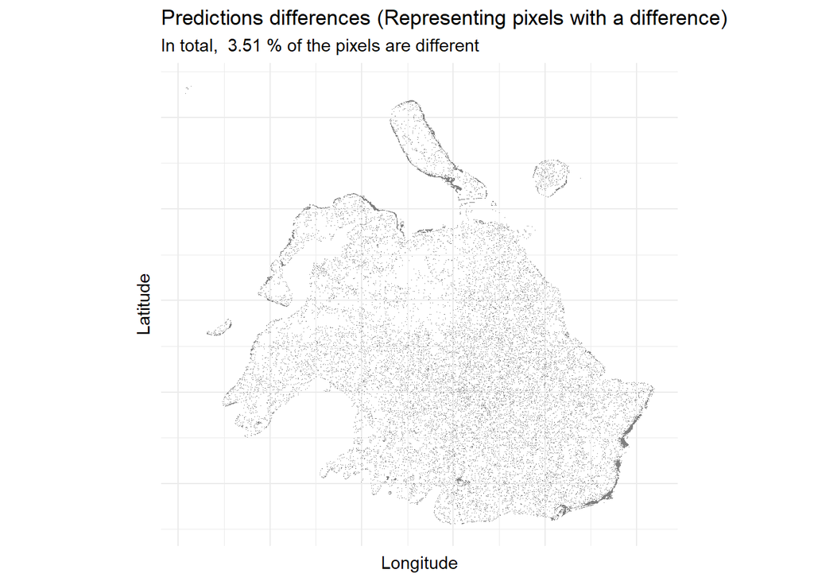

```r
#Plot the map pf difference"s
p_diff <- combined_df%>%
  filter(diff =="Change") %>%
  ggplot()+
  aes(x = x, y = y) +
  geom_raster(aes(fill = diff_class)) +
  scale_fill_manual(values = "orange", name = "Legend") +
  coord_fixed() +
  theme_minimal() +
  labs(title = "Predictions differences (Representing pixels with a difference)",
       subtitle = paste("In total, ", pc_diff, "% of the pixels are different") ,
       x = "Longitude", y = "Latitude")+
  theme(legend.position = "none",
        axis.text.x=element_blank(),
        axis.ticks.x=element_blank(),
        axis.text.y=element_blank(),
        axis.ticks.y=element_blank())

p_diff
```

```r
#Plot the map highlighting changes
p_RF_diff <- ggplot(combined_df, aes(x = x, y = y)) +
  geom_raster(aes(fill = diff_class),  alpha = 0.5) +
 scale_fill_manual(values = class_colors_N,
                    name = "Land Cover") +
  coord_fixed() +
  theme_minimal() +
  labs(title = "Predictions differences",
       subtitle = "RF predictions vs MNL predictions",
       x = "Longitude", y = "Latitude")+
  theme(axis.text.x=element_blank(),
        axis.ticks.x=element_blank(),
        axis.text.y=element_blank(),
        axis.ticks.y=element_blank())

# p_RF_diff
```

### Statistics on the differences

> How important are the differences between the 2 models?

```r
nb_diff <- combined_df %>%
  filter(diff=="Change") %>%
  nrow()
pc_diff <- round(100 * nb_diff / nrow(combined_df),2)
```

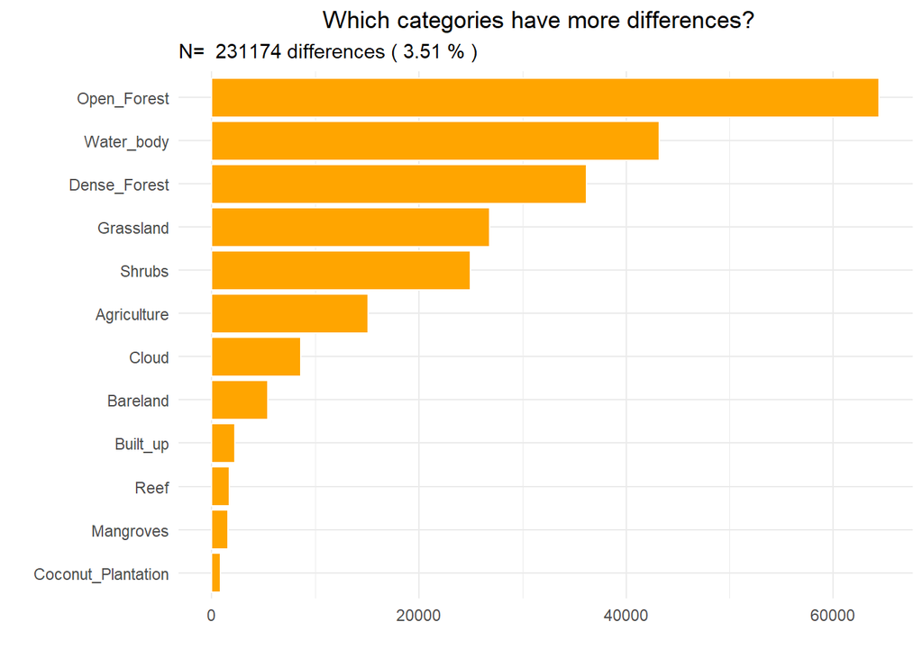

```r
combined_df %>%
  filter(diff=="Change") %>%
  mutate(prediction_RF = fct_infreq(prediction_RF) %>% fct_rev()) %>%  # Reorder and reverse factor levels
  ggplot() +
  geom_bar(aes(y = prediction_RF), colour="white", fill = "orange") +
  theme_minimal() +
  theme(plot.title = element_text(hjust = 0.5))+
  labs(x = "", y = "",
       subtitle = paste ( "N= ", nrow(combined_df %>% filter(diff=="Change")), "differences (", pc_diff, "% )")
       )  +
  ggtitle("Which categories have more differences?  ")
```

### Alluvial (*Sankey*) graphic to visualize the differences in predictions

In this graphic, the RF model is represented vertically by a bar on the left. Each prediction is represented as a color in a stacked bar. The SMOTE model is on the right. The *ribbons* in between represent the flows between categories. The width of the *ribbons* corresponds to the number of predictions differing from one class to another.

```r
# Summarize the data to count occurrences of each prediction pair
# We remove Water_body to have a better view

flow_data <- combined_df %>%
  filter(prediction_RF !="Water_body" )%>%
  count(prediction_RF, prediction_smote, name = "Frequency")
```

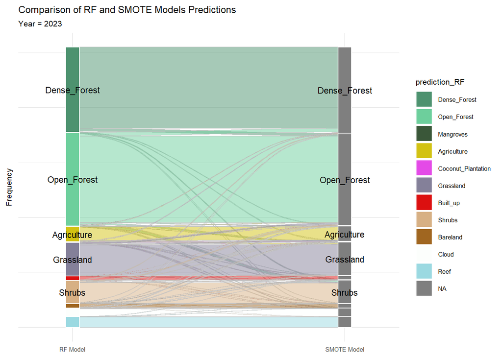

```r
library(ggalluvial)

mypalette <- class_colors[-c(8)] # Removing Water_body color!!

p_S <- ggplot(flow_data,
       aes(axis1 = prediction_RF, axis2 = prediction_smote, y = Frequency)) +
  geom_alluvium(aes(fill = prediction_RF), width = 0, color= "grey") +
  geom_stratum(width = 1/20, aes(fill = prediction_RF ), color = "white" ) +
  geom_text(stat = "stratum", aes(label = after_stat(stratum)),
            size = 3, color = "black",  min.y = 100000) +  # min.y to remove small categories label
  scale_x_discrete(limits = c("RF Model", "SMOTE Model"), expand = c(0.15, 0.05)) +
  scale_fill_manual(values = mypalette)  +
  labs(title = "Comparison of RF and SMOTE Models Predictions",
       subtitle = paste("Year =", StudyYear)) +
  theme_minimal() +
  theme(text = element_text(size = 8),
        axis.text.y = element_blank())

p_S
```

### Comparing Random Forest model with Blanca’s RF model

```r
# Read the TIFF file
BlancaFile <- ifelse(StudyYear== 2020,
                          paste0("Data/",MyDir,"/ROI",StudyYear,"/pred_landcover_",StudyYear,"_vROIs2.tif"),
                           paste0("Data/",MyDir,"/ROI",StudyYear,"/pred_landcover_2023_vROIs1.tif")                                                  )


raster_RF_Blanca <- rast(BlancaFile)
# Convert the raster to a data frame for ggplot2
raster_df_Blanca <- as.data.frame(raster_RF_Blanca, xy = TRUE)

# Change prediction's name to be independent of the year!
raster_df_Blanca <-raster_df_Blanca %>%
  rename_with(~ "Pred", starts_with("pred_landcover"))


# Convert raster values to a factor with labels
raster_df_Blanca$Pred <- factor(raster_df_Blanca$Pred, levels = names(class_labels), labels = class_labels)
```

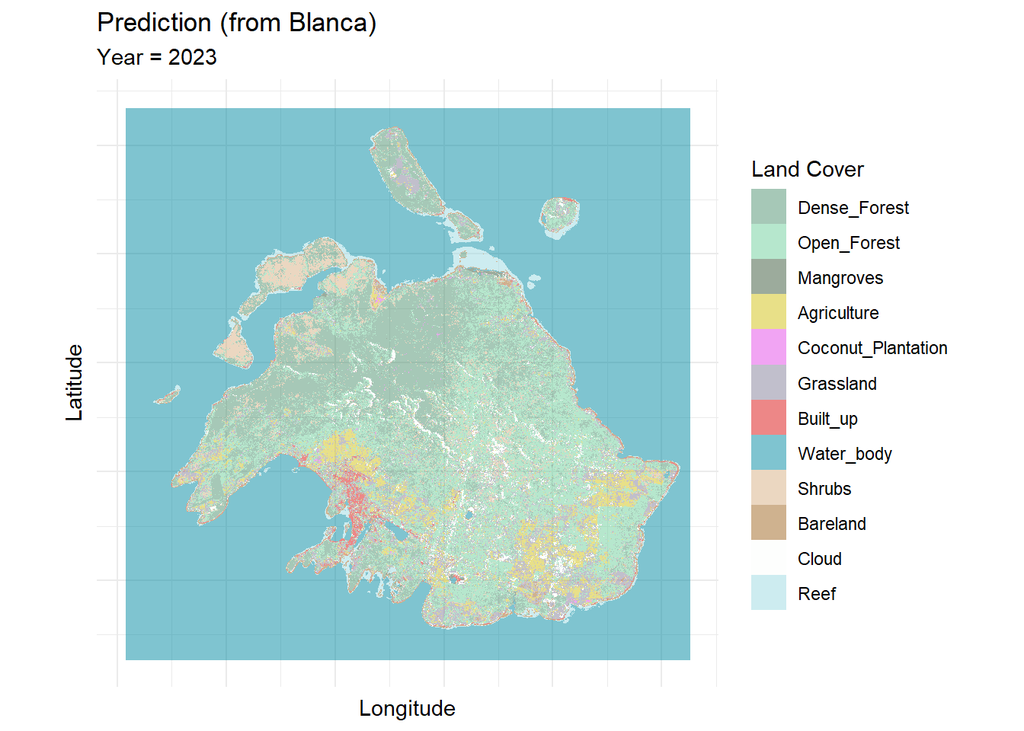

```r
# Plot using ggplot2
p_Blanca <- ggplot() +
  geom_raster(data = raster_df_Blanca, aes(x = x, y = y, fill = Pred), alpha = 0.5 ) +
  scale_fill_manual(values = class_colors, name = "Land Cover") +
  coord_fixed() +
  theme_minimal() +
  labs(title = "Prediction (from Blanca) ",
       subtitle = paste("Year =", StudyYear),
       x = "Longitude",
       y = "Latitude")+
  theme(axis.text.x=element_blank(),
        axis.ticks.x=element_blank(),
        axis.text.y=element_blank(),
        axis.ticks.y=element_blank())

p_Blanca
```

### Visualizing the differences

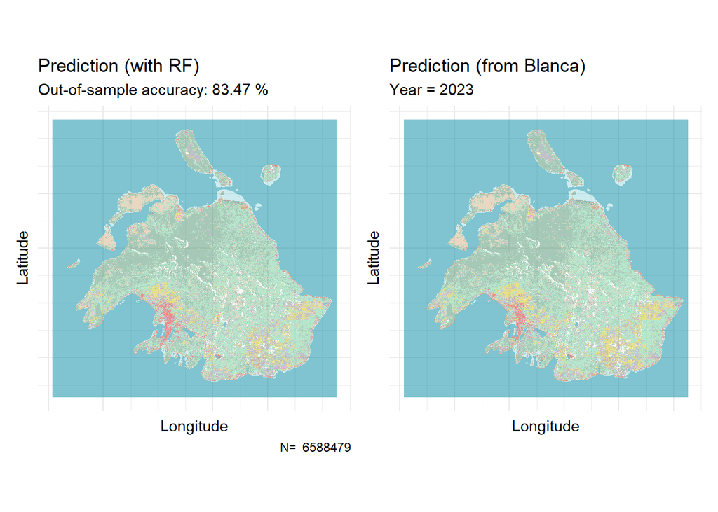

```r
# Combine the plots
# removing the legend for one plot
p_RF <- p_RF + theme(legend.position = "none")
p_Blanca <- p_Blanca + theme(legend.position = "none")


RFvsBlanca <- (p_RF |  p_Blanca)

# Display the combined plot
print(RFvsBlanca)
```

### Statistics on the differences

> How important are the differences between the 2 models?

```r
# Computing the differences. We continue with a combined data frame (already smotet there)

# Merge the data frames on x and y coordinates
combined_df_Q <- combined_df %>%
  inner_join(raster_df_Blanca, by = c("x", "y"))

combined_df_Q <- combined_df_Q %>%
  rename(prediction_Blanca = Pred)

# Create a new column indicating whether the predictions are the same or different
# Affecting class = 0 to difference
combined_df_Q <- combined_df_Q %>%
  mutate(diff_Q = ifelse(prediction_RF == prediction_Blanca, "No Change", "Change"))%>%
   mutate(diff_class_Q = ifelse(prediction_RF == prediction_Blanca, prediction_RF, "0"))

# Convert raster values to a factor with labels
combined_df_Q$diff_class_Q <- factor(combined_df_Q$diff_class_Q, levels = names(class_labels_N), labels = class_labels_N)
```

```r
nb_diff_Q <- combined_df_Q %>%
  filter(diff_Q=="Change") %>%
  nrow()
pc_diff_Q <- round(100 * nb_diff_Q / nrow(combined_df_Q),2)
```

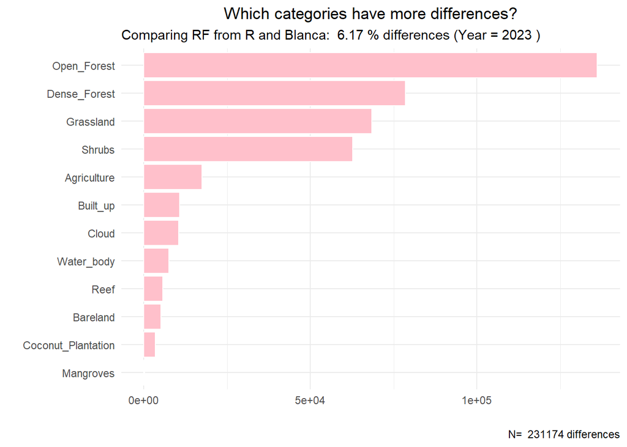

```r
combined_df_Q %>%
  filter(diff_Q=="Change") %>%
  mutate(prediction_RF = fct_infreq(prediction_RF) %>% fct_rev()) %>%  # Reorder and reverse factor levels
  ggplot() +
  geom_bar(aes(y = prediction_RF), colour="white", fill = "pink") +
  labs( title = "Which categories have more differences?",
        subtitle = paste("Comparing RF from R and Blanca: ",pc_diff_Q, "% differences (Year =", StudyYear, ")"),
        caption = paste( "N= ", nrow(combined_df_Q %>% filter(diff=="Change")), "differences"),
        x = "", y = "")  +
     theme_minimal() +
  theme(plot.title = element_text(hjust = 0.5))
```

```r
# Summarize the data to count occurrences of each prediction pair
# We remove Water_body to have a better view

flow_data_Q <- combined_df_Q %>%
  filter(prediction_RF !="Water_body" )%>%
  count(prediction_RF, prediction_Blanca, name = "Frequency")
```

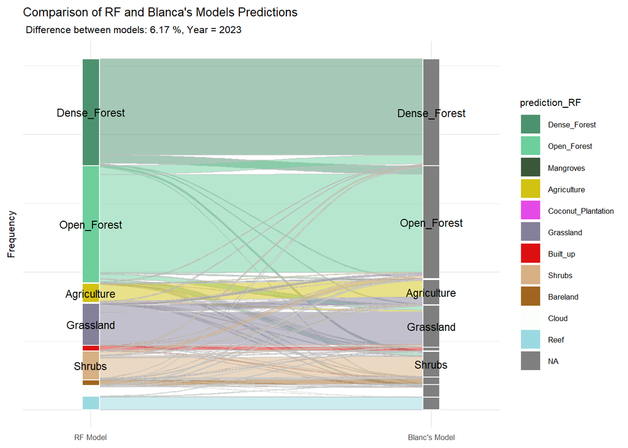

```r
library(ggalluvial)

mypalette <- class_colors[-c(8)] # Removing Water_body color!!

p_S <- ggplot(flow_data_Q,
       aes(axis1 = prediction_RF, axis2 = prediction_Blanca, y = Frequency)) +
  geom_alluvium(aes(fill = prediction_RF), width = 0, color= "grey") +
  geom_stratum(width = 1/20, aes(fill = prediction_RF ), color = "white" ) +
  geom_text(stat = "stratum", aes(label = after_stat(stratum)),
            size = 3, color = "black",  min.y = 100000) +  # min.y to remove small categories label
  scale_x_discrete(limits = c("RF Model", "Blanc's Model"), expand = c(0.15, 0.05)) +
  scale_fill_manual(values = mypalette)  +
  labs(title = "Comparison of RF and Blanca's Models Predictions",
       subtitle = paste(" Difference between models:",pc_diff_Q,"%, Year =", StudyYear)) +
  theme_minimal() +
  theme(text = element_text(size = 8),
        axis.text.y = element_blank())

p_S
```

[^1]: See *e.g..* https://stats.stackexchange.com/questions/82162/cohens-kappa-in-plain-english for the detail of the computation of $p_e$.
[^2]: By design models use different data sets and as such should not really be compared *in-sample*. For example, “*down-sampling*” decreases the number of instances in the majority class, and so removes observations, while “*up-sampling*” duplicates the observations in the minority classes and mechanically increases the sample size.